# Lab 2: Statistics

Lists, Numbers, Strings, Dataframes, Subsetting

Author

Bogdan G. Popescu

# 1 Intro

In this lab, we are doing the basics in R. We learn how to remove elements from list, how to work with dataframes, how to load csv files, how to merge data, and how to produce a scatter plot.

# Instructions

- Download the *.qmd file from [here](https://www.dropbox.com/scl/fi/ijxh28fxsqxwqlv7j2t81/lab2_model.qmd?rlkey=8q60w64z6snjsr99wim69a577&dl=0)
- Place it in the relavant folder “Lab 2”
- Open the *.qmd file

# 2 Removing Elements from Lists

## Question 1

Remove the word “literature” from the following vector and create a new object

```r
list_fields <- c("politics", "philosophy", "literature", "chemistry")
list_fields_new<-list_fields[list_fields!="literature"]
list_fields_new
```

```
[1] "politics"   "philosophy" "chemistry"
```

## Question 2

```r
list_no<-c(11, 12, 13, 14, 15, 16, 17)
new_list_no <- list_no[list_no <= 13 | list_no >= 15]
new_list_no
```

```
[1] 11 12 13 15 16 17
```

## Question 3

Remove from the following list, “word”, “sentence”, “books” using the %in% operator.

```r
list_words<-c("random", "word", "sentence", "books")

exclusion_list<-c("word", "sentence", "books")

(list_words %in% exclusion_list)
```

```
[1] FALSE  TRUE  TRUE  TRUE
```

```r
!(list_words %in% exclusion_list)
```

```
[1]  TRUE FALSE FALSE FALSE
```

```r
list_words[!(list_words %in% exclusion_list)]
```

```
[1] "random"
```

```r
student_group1<-c("Alex", "Helen", "Charlie")
student_group2<-c("Ollie", "James", "Ellie", "Charlie")

student_group2 %in% student_group1
```

```
[1] FALSE FALSE FALSE  TRUE
```

```r
list_words_new<-list_words[!(list_words %in% exclusion_list)]
list_words_new
```

```
[1] "random"
```

```r
"four" > "five"
```

```
[1] TRUE
```

# 3 Counting string elements

## Question 4

Explain in your words: Why does the following “four” > “five” return TRUE

```r
"four" > "five"
```

```
[1] TRUE
```

```r
#Because "o" comes after "i" alphabetically
```

```r
nchar("four")
```

```
[1] 4
```

# 4 Dealing with Missing Observations

## Question 5

Remove the missing data from the following list

```r
list_no <- c(1, 2, 3, 4, NA, 5, 6)
#ANSWER

#is.na(list_no)
#!is.na(list_no)

list_no_updated<-list_no[!is.na(list_no)]
list_no_updated
```

```
[1] 1 2 3 4 5 6
```

# 5 Mean and Median

## Question 6

Calculate the mean and median from the following list of numbers

```r
list_no<-c(30, 12, NA, 14, NA)

mean(list_no, na.rm=TRUE)
```

```
[1] 18.66667
```

```r
median(list_no, na.rm=TRUE)
```

```
[1] 14
```

# 6 Dataframes

## Question 7

Create the following dataframe

```r
#Option1
student<-c('Alex', 'Jane', 'Tom', 'Lilly', 'Turner', 'Ruby', 'Nick')
grade<-c(77, 81, 89, 83, 99, 92, 97)

df<-data.frame(student, grade)

#Option2
df <- data.frame(student=c('Alex', 'Jane', 'Tom', 'Lilly', 'Turner', 'Ruby', 'Nick'),
                 grade=c(77, 81, 89, 83, 99, 92, 97))
df
```

| student | grade |
| --- | --- |
| Alex | 77 |
| Jane | 81 |
| Tom | 89 |
| Lilly | 83 |
| Turner | 99 |
| Ruby | 92 |
| Nick | 97 |

## Question 8

Create a new dataframe with only Alex, Jane and Turner

```r
new_df<-subset(df, student=="Alex" | student == "Jane" |  student == "Turner")
new_df
```

|  | student | grade |
| --- | --- | --- |
| 1 | Alex | 77 |
| 2 | Jane | 81 |
| 5 | Turner | 99 |

## Question 9

What is the average grade for the entire class

```r
mean(df$grade)
```

```
[1] 88.28571
```

## Question 10

What is the mean of Alex, Jane, and Turner’s grades

```r
new_df<-subset(df, student=="Alex" | student == "Jane" |  student == "Turner")
mean(new_df$grade)
```

```
[1] 85.66667
```

# 7 Max and Min

## Question 11

What is the highest grade?

```r
max(df$grade)
```

```
[1] 99
```

```r
max_grade<-max(df$grade)
max_grade
```

```
[1] 99
```

## Question 12

What is the lowest grade?

```r
min_grade<-min(df$grade)
min_grade
```

```
[1] 77
```

# 8 Subsetting

## Question 13

Who is student with the highest grade?

```r
df$student[df$grade==max_grade]
```

```
[1] "Turner"
```

## Question 14

Who is the student with the lowest grade?

```r
df$student[df$grade==min_grade]
```

```
[1] "Alex"
```

# 9 Removing items from list based on index

## Question 15

Extract the second element from the following list

```r
list_new<-c("el1", "el2", "el3")
list_new[2]
```

```
[1] "el2"
```

## Question 16

Extract the last element from the following list

```r
list_new<-c("el1", "el2", "el3")
list_new[length(list_new)]
```

```
[1] "el3"
```

# 10 Merging Datsets

## Question 17

Merging Datsets

1. Load the life_expectancy and urbanization datasets
- [Life Expectancy](https://www.dropbox.com/scl/fi/3h5vr0ak3xobzqb4k3jt3/life-expectancy.csv?rlkey=w6iwbjdd1dkyuck6z3h0w1tql&dl=0)
- [Urbanization](https://www.dropbox.com/scl/fi/8uj8h6y8itijctd80tb61/share-of-population-urban.csv?rlkey=5ajqwhox3gl9lmt0bku8zb54q&dl=0)

```r
#Removing previous datasets in memory
rm(list = ls())
#Setting path
setwd("/Users/bgpopescu/Dropbox/john_cabot/teaching/stats/lab2/")
life_expectancy_df <- read.csv(file = './life-expectancy.csv')
urbanization_df <- read.csv(file = './share-of-population-urban.csv')
```

2. Calculate the mean by country for life_expectancy

```r
library(dplyr)
life_expectancy_df2<-life_expectancy_df%>%
  dplyr::group_by(Code)%>%
  dplyr::summarize(life_exp_mean=mean(Life.expectancy.at.birth..historical.))

head(life_expectancy_df2, 5)
```

| Code | life_exp_mean |
| --- | --- |
|  | 62.11781 |
| ABW | 70.25972 |
| AFG | 45.38333 |
| AGO | 45.08466 |
| AIA | 69.44028 |

3. Remove the countries which have missing continents

```r
life_expectancy_df3<-subset(life_expectancy_df2, life_expectancy_df2$Code!="")
head(life_expectancy_df3, 3)
```

| Code | life_exp_mean |
| --- | --- |
| ABW | 70.25972 |
| AFG | 45.38333 |
| AGO | 45.08466 |

4. Calculate the mean by country for urbanization

```r
urbanization_df2<-urbanization_df%>%
  dplyr::group_by(Code)%>%
  dplyr::summarize(urb_mean=mean(Urban.population....of.total.population.))
```

5. Remove the countries which have missing continents

```r
#Removing continents
urbanization_df3<-subset(urbanization_df2, urbanization_df2$Code!="")
```

6. Perform a left merge

```r
merged_df<-left_join(life_expectancy_df3, urbanization_df3, by = c("Code"="Code"))
```

7. Remove NA values

```r
library(tidyr)
merged_df<-merged_df%>%
  drop_na()
```

# 11 Scatterplots

8. Creating a scatterplot

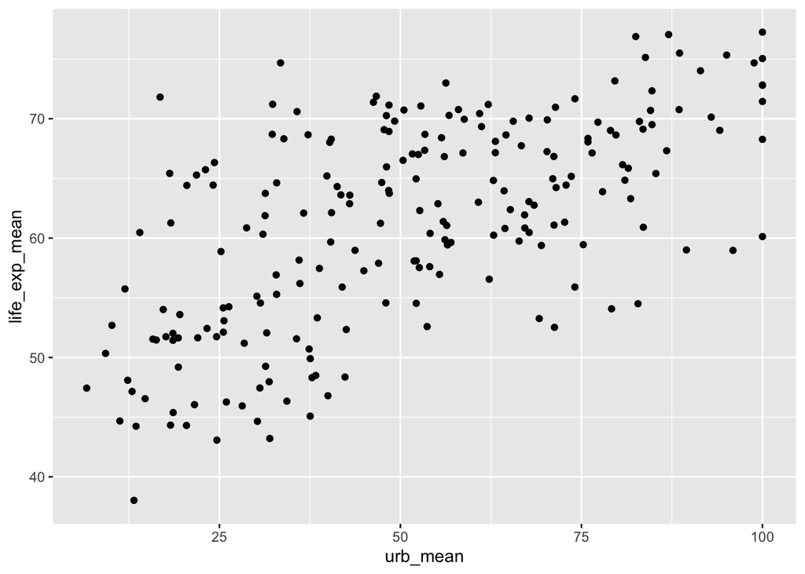

```r
library(ggplot2)
ggplot(merged_df, aes(x=urb_mean, y=life_exp_mean)) +
  geom_point()
```